# SAKSHI AGGARWAL

## Intern at The Sparks Foundation - Data Science and Business Analytics

## Task 3

Dataset-https://bit.ly/3i4rbWl

```python
import pandas as pd
import numpy as np
```

```python
import matplotlib.pyplot as plt
%matplotlib inline
```

```python
df = pd.read_csv("C:\\Users\\pc\\Downloads\\SampleSuperstore.csv")
```

```python
df.shape
```

```
(9994, 13)
```

```python
df = pd.DataFrame(df)
```

```python
#To know heads of data with initial 5 entries
df.head()
```

|  | Ship Mode | Segment | Country | City | State | Postal Code | Region | Category | Sub-Category | Sales | Quantity | Discount | Profit |
| --- | --- | --- | --- | --- | --- | --- | --- | --- | --- | --- | --- | --- | --- |
| 0 | Second Class | Consumer | United States | Henderson | Kentucky | 42420 | South | Furniture | Bookcases | 261.9600 | 2 | 0.00 | 41.9136 |
| 1 | Second Class | Consumer | United States | Henderson | Kentucky | 42420 | South | Furniture | Chairs | 731.9400 | 3 | 0.00 | 219.5820 |
| 2 | Second Class | Corporate | United States | Los Angeles | California | 90036 | West | Office Supplies | Labels | 14.6200 | 2 | 0.00 | 6.8714 |
| 3 | Standard Class | Consumer | United States | Fort Lauderdale | Florida | 33311 | South | Furniture | Tables | 957.5775 | 5 | 0.45 | -383.0310 |
| 4 | Standard Class | Consumer | United States | Fort Lauderdale | Florida | 33311 | South | Office Supplies | Storage | 22.3680 | 2 | 0.20 | 2.5164 |

```python
#To know last 5 entries
df.tail()
```

|  | Ship Mode | Segment | Country | City | State | Postal Code | Region | Category | Sub-Category | Sales | Quantity | Discount | Profit |
| --- | --- | --- | --- | --- | --- | --- | --- | --- | --- | --- | --- | --- | --- |
| 9989 | Second Class | Consumer | United States | Miami | Florida | 33180 | South | Furniture | Furnishings | 25.248 | 3 | 0.2 | 4.1028 |
| 9990 | Standard Class | Consumer | United States | Costa Mesa | California | 92627 | West | Furniture | Furnishings | 91.960 | 2 | 0.0 | 15.6332 |
| 9991 | Standard Class | Consumer | United States | Costa Mesa | California | 92627 | West | Technology | Phones | 258.576 | 2 | 0.2 | 19.3932 |
| 9992 | Standard Class | Consumer | United States | Costa Mesa | California | 92627 | West | Office Supplies | Paper | 29.600 | 4 | 0.0 | 13.3200 |
| 9993 | Second Class | Consumer | United States | Westminster | California | 92683 | West | Office Supplies | Appliances | 243.160 | 2 | 0.0 | 72.9480 |

```python
#to get information about the data
df.info()
```

```
<class 'pandas.core.frame.DataFrame'>
RangeIndex: 9994 entries, 0 to 9993
Data columns (total 13 columns):
 #   Column        Non-Null Count  Dtype
---  ------        --------------  -----
 0   Ship Mode     9994 non-null   object
 1   Segment       9994 non-null   object
 2   Country       9994 non-null   object
 3   City          9994 non-null   object
 4   State         9994 non-null   object
 5   Postal Code   9994 non-null   int64
 6   Region        9994 non-null   object
 7   Category      9994 non-null   object
 8   Sub-Category  9994 non-null   object
 9   Sales         9994 non-null   float64
 10  Quantity      9994 non-null   int64
 11  Discount      9994 non-null   float64
 12  Profit        9994 non-null   float64
dtypes: float64(3), int64(2), object(8)
memory usage: 1015.1+ KB
```

```python
df.describe()
```

|  | Postal Code | Sales | Quantity | Discount | Profit |
| --- | --- | --- | --- | --- | --- |
| count | 9994.000000 | 9994.000000 | 9994.000000 | 9994.000000 | 9994.000000 |
| mean | 55190.379428 | 229.858001 | 3.789574 | 0.156203 | 28.656896 |
| std | 32063.693350 | 623.245101 | 2.225110 | 0.206452 | 234.260108 |
| min | 1040.000000 | 0.444000 | 1.000000 | 0.000000 | -6599.978000 |
| 25% | 23223.000000 | 17.280000 | 2.000000 | 0.000000 | 1.728750 |
| 50% | 56430.500000 | 54.490000 | 3.000000 | 0.200000 | 8.666500 |
| 75% | 90008.000000 | 209.940000 | 5.000000 | 0.200000 | 29.364000 |
| max | 99301.000000 | 22638.480000 | 14.000000 | 0.800000 | 8399.976000 |

```python
#to drop column which are not so important for analysis
df.drop(["Country","Postal Code"], axis=1, inplace = True)
```

```python
df
```

|  | Ship Mode | Segment | City | State | Region | Category | Sub-Category | Sales | Quantity | Discount | Profit |
| --- | --- | --- | --- | --- | --- | --- | --- | --- | --- | --- | --- |
| 0 | Second Class | Consumer | Henderson | Kentucky | South | Furniture | Bookcases | 261.9600 | 2 | 0.00 | 41.9136 |
| 1 | Second Class | Consumer | Henderson | Kentucky | South | Furniture | Chairs | 731.9400 | 3 | 0.00 | 219.5820 |
| 2 | Second Class | Corporate | Los Angeles | California | West | Office Supplies | Labels | 14.6200 | 2 | 0.00 | 6.8714 |
| 3 | Standard Class | Consumer | Fort Lauderdale | Florida | South | Furniture | Tables | 957.5775 | 5 | 0.45 | -383.0310 |
| 4 | Standard Class | Consumer | Fort Lauderdale | Florida | South | Office Supplies | Storage | 22.3680 | 2 | 0.20 | 2.5164 |
| ... | ... | ... | ... | ... | ... | ... | ... | ... | ... | ... | ... |
| 9989 | Second Class | Consumer | Miami | Florida | South | Furniture | Furnishings | 25.2480 | 3 | 0.20 | 4.1028 |
| 9990 | Standard Class | Consumer | Costa Mesa | California | West | Furniture | Furnishings | 91.9600 | 2 | 0.00 | 15.6332 |
| 9991 | Standard Class | Consumer | Costa Mesa | California | West | Technology | Phones | 258.5760 | 2 | 0.20 | 19.3932 |
| 9992 | Standard Class | Consumer | Costa Mesa | California | West | Office Supplies | Paper | 29.6000 | 4 | 0.00 | 13.3200 |
| 9993 | Second Class | Consumer | Westminster | California | West | Office Supplies | Appliances | 243.1600 | 2 | 0.00 | 72.9480 |

9994 rows × 11 columns

```python
df.describe()
```

|  | Sales | Quantity | Discount | Profit |
| --- | --- | --- | --- | --- |
| count | 9994.000000 | 9994.000000 | 9994.000000 | 9994.000000 |
| mean | 229.858001 | 3.789574 | 0.156203 | 28.656896 |
| std | 623.245101 | 2.225110 | 0.206452 | 234.260108 |
| min | 0.444000 | 1.000000 | 0.000000 | -6599.978000 |
| 25% | 17.280000 | 2.000000 | 0.000000 | 1.728750 |
| 50% | 54.490000 | 3.000000 | 0.200000 | 8.666500 |
| 75% | 209.940000 | 5.000000 | 0.200000 | 29.364000 |
| max | 22638.480000 | 14.000000 | 0.800000 | 8399.976000 |

```python
df.columns
```

```
Index(['Ship Mode', 'Segment', 'City', 'State', 'Region', 'Category',
       'Sub-Category', 'Sales', 'Quantity', 'Discount', 'Profit'],
      dtype='object')
```

```python
print('Total sales are{}'.format(df['Sales'].sum()))
```

```
Total sales are2297200.8603000003
```

```python
print('Total profits are{}'.format(df['Profit'].sum()))
```

```
Total profits are286397.0217
```

```python
df.shape
```

```
(9994, 11)
```

```python
df.isnull().sum(axis=0).to_frame()
```

|  | 0 |
| --- | --- |
| Ship Mode | 0 |
| Segment | 0 |
| City | 0 |
| State | 0 |
| Region | 0 |
| Category | 0 |
| Sub-Category | 0 |
| Sales | 0 |
| Quantity | 0 |
| Discount | 0 |
| Profit | 0 |

```python
df["Category"].unique()
```

```
array(['Furniture', 'Office Supplies', 'Technology'], dtype=object)
```

```python
df["Sub-Category"].unique()
```

```
array(['Bookcases', 'Chairs', 'Labels', 'Tables', 'Storage',
       'Furnishings', 'Art', 'Phones', 'Binders', 'Appliances', 'Paper',
       'Accessories', 'Envelopes', 'Fasteners', 'Supplies', 'Machines',
       'Copiers'], dtype=object)
```

```python
df['Category'].value_counts()
```

```
Office Supplies    6026
Furniture          2121
Technology         1847
Name: Category, dtype: int64
```

```python
df['Sub-Category'].value_counts()
```

```
Binders        1523
Paper          1370
Furnishings     957
Phones          889
Storage         846
Art             796
Accessories     775
Chairs          617
Appliances      466
Labels          364
Tables          319
Envelopes       254
Bookcases       228
Fasteners       217
Supplies        190
Machines        115
Copiers          68
Name: Sub-Category, dtype: int64
```

```python
df['Region'].value_counts()
```

```
West       3203
East       2848
Central    2323
South      1620
Name: Region, dtype: int64
```

```python
df.nunique()
```

```
Ship Mode          4
Segment            3
City             531
State             49
Region             4
Category           3
Sub-Category      17
Sales           5825
Quantity          14
Discount          12
Profit          7287
dtype: int64
```

```python
df.dtypes
```

```
Ship Mode        object
Segment          object
City             object
State            object
Region           object
Category         object
Sub-Category     object
Sales           float64
Quantity          int64
Discount        float64
Profit          float64
dtype: object
```

```python
df.duplicated().sum()
```

```
50
```

```python
df.drop_duplicates()
```

|  | Ship Mode | Segment | City | State | Region | Category | Sub-Category | Sales | Quantity | Discount | Profit |
| --- | --- | --- | --- | --- | --- | --- | --- | --- | --- | --- | --- |
| 0 | Second Class | Consumer | Henderson | Kentucky | South | Furniture | Bookcases | 261.9600 | 2 | 0.00 | 41.9136 |
| 1 | Second Class | Consumer | Henderson | Kentucky | South | Furniture | Chairs | 731.9400 | 3 | 0.00 | 219.5820 |
| 2 | Second Class | Corporate | Los Angeles | California | West | Office Supplies | Labels | 14.6200 | 2 | 0.00 | 6.8714 |
| 3 | Standard Class | Consumer | Fort Lauderdale | Florida | South | Furniture | Tables | 957.5775 | 5 | 0.45 | -383.0310 |
| 4 | Standard Class | Consumer | Fort Lauderdale | Florida | South | Office Supplies | Storage | 22.3680 | 2 | 0.20 | 2.5164 |
| ... | ... | ... | ... | ... | ... | ... | ... | ... | ... | ... | ... |
| 9989 | Second Class | Consumer | Miami | Florida | South | Furniture | Furnishings | 25.2480 | 3 | 0.20 | 4.1028 |
| 9990 | Standard Class | Consumer | Costa Mesa | California | West | Furniture | Furnishings | 91.9600 | 2 | 0.00 | 15.6332 |
| 9991 | Standard Class | Consumer | Costa Mesa | California | West | Technology | Phones | 258.5760 | 2 | 0.20 | 19.3932 |
| 9992 | Standard Class | Consumer | Costa Mesa | California | West | Office Supplies | Paper | 29.6000 | 4 | 0.00 | 13.3200 |
| 9993 | Second Class | Consumer | Westminster | California | West | Office Supplies | Appliances | 243.1600 | 2 | 0.00 | 72.9480 |

9944 rows × 11 columns

```python
#to know relation between different variables
df.corr()
```

|  | Sales | Quantity | Discount | Profit |
| --- | --- | --- | --- | --- |
| Sales | 1.000000 | 0.200795 | -0.028190 | 0.479064 |
| Quantity | 0.200795 | 1.000000 | 0.008623 | 0.066253 |
| Discount | -0.028190 | 0.008623 | 1.000000 | -0.219487 |
| Profit | 0.479064 | 0.066253 | -0.219487 | 1.000000 |

```python
df.cov()
```

|  | Sales | Quantity | Discount | Profit |
| --- | --- | --- | --- | --- |
| Sales | 388434.455308 | 278.459923 | -3.627228 | 69944.096586 |
| Quantity | 278.459923 | 4.951113 | 0.003961 | 34.534769 |
| Discount | -3.627228 | 0.003961 | 0.042622 | -10.615173 |
| Profit | 69944.096586 | 34.534769 | -10.615173 | 54877.798055 |

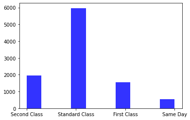

```python
#to know most prevelant mode of shipment
num_bins= 10
plt.hist(df['Ship Mode'],num_bins, facecolor = 'blue', alpha = 0.8)
plt.show()
```

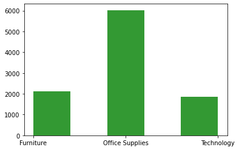

```python
#to know which category providing maximum sales
num_bins= 5
plt.hist(df['Category'],num_bins, facecolor = 'green', alpha = 0.8)
plt.show()
```

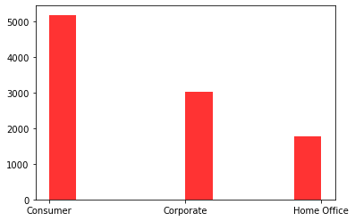

```python
#to know which segment is most important
num_bins= 10
plt.hist(df['Segment'],num_bins, facecolor = 'red', alpha = 0.8)
plt.show()
plt.tight_layout()
```

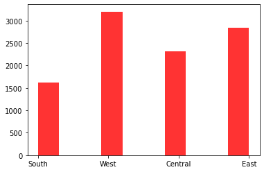

```python
#to know the contibution of differnet regions in sales
num_bins= 10
plt.hist(df['Region'],num_bins, facecolor = 'red', alpha = 0.8)
plt.show()
```

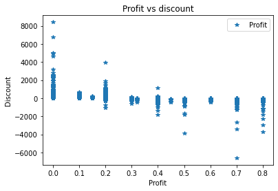

```python
#to know relation between profit and discount
df.plot(x='Discount', y='Profit',style='*')
plt.title('Profit vs discount')
plt.xlabel('Profit')
plt.ylabel('Discount')
plt.show()
```

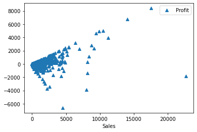

```python
#to know relation between sales and profit
df.plot(x='Sales',y='Profit',style="^")
```

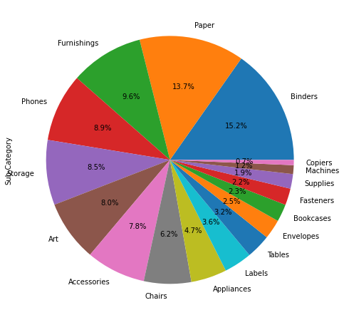

```python
#to know the share of differnet sub-categories
plt.figure(figsize=(10,8))
df['Sub-Category'].value_counts().plot.pie(autopct='%1.1f%%')
plt.show()
```

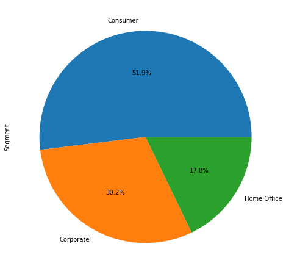

```python
#to know the share of different segments
plt.figure(figsize=(10,8))
df['Segment'].value_counts().plot.pie(autopct='%1.1f%%')
plt.show()
```

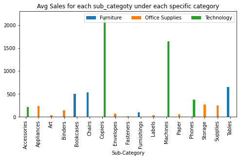

```python
#to know avg sales of sub categories under each category
avg_sales=df.groupby(['Sub-Category','Category'])['Sales'].mean().unstack()
plt.rcParams["figure.figsize"] = (8,4)
avg_sales.plot(kind='bar')
plt.title('Avg Sales for each sub_categoty under each specific category')
plt.legend(loc='upper right',ncol=4)
plt.show()
```

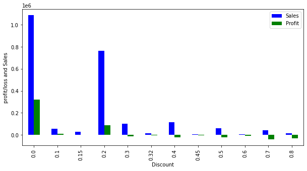

```python
#to profit and sales associated with different discount rates
df.groupby('Discount')[['Sales','Profit']].sum().plot.bar(color = ["blue","green"],figsize=(10,5))
plt.ylabel("profit/loss and Sales")
plt.xlabel("Discount")
plt.show()
```

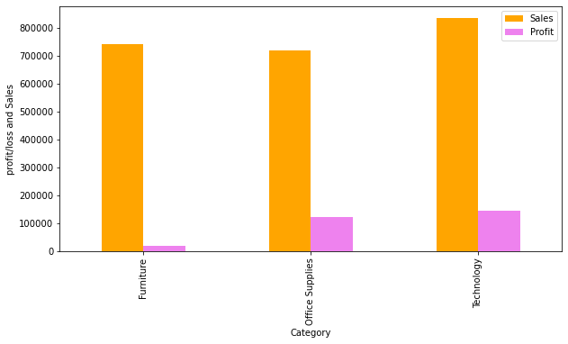

```python
#to know sales and profit under each category
df.groupby('Category')[['Sales','Profit']].sum().plot.bar(color = ["orange","violet"],figsize=(10,5))
plt.ylabel("profit/loss and Sales")
plt.xlabel("Category")
plt.show()
```

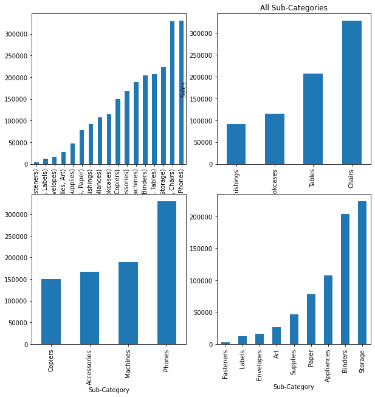

```python
#to know sales under each category
fig=plt.figure()
ax0=fig.add_subplot(2,2,1)
ax1=fig.add_subplot(2,2,2)
ax2=fig.add_subplot(2,2,3)
ax3=fig.add_subplot(2,2,4)

sales = df.groupby(["Category","Sub-Category"]).Sales.sum()
Profits = df.groupby(["Category","Sub-Category"]).Profit.sum()

sales["Furniture"].sort_values(ascending=True).plot(kind='bar',figsize=(10,10),ax=ax1)
ax1.set_title("Furniture")
ax1.set_xlabel("Sub-Categories")
ax1.set_ylabel("Sales")

sales["Technology"].sort_values(ascending=True).plot(kind='bar',figsize=(10,10),ax=ax2)
ax1.set_title("Technology")
ax1.set_xlabel("Sub-Categories")
ax1.set_ylabel("Sales")

sales["Office Supplies"].sort_values(ascending=True).plot(kind='bar',figsize=(10,10),ax=ax3)
ax1.set_title("Office Supplies")
ax1.set_xlabel("Sub-Categories")
ax1.set_ylabel("Sales")

sales.sort_values(ascending=True).plot(kind='bar',figsize=(10,10),ax=ax0)
ax1.set_title("All Sub-Categories")
ax1.set_xlabel("Sub-Categories")
ax1.set_ylabel("Sales")
```

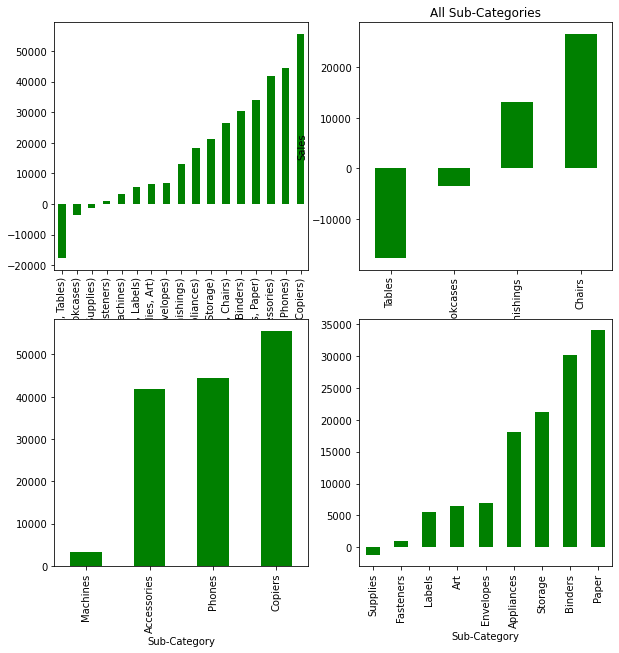

```python
#to know profits under each category
fig=plt.figure()
ax0=fig.add_subplot(2,2,1)
ax1=fig.add_subplot(2,2,2)
ax2=fig.add_subplot(2,2,3)
ax3=fig.add_subplot(2,2,4)

sales = df.groupby(["Category","Sub-Category"]).Sales.sum()
Profits = df.groupby(["Category","Sub-Category"]).Profit.sum()

Profits["Furniture"].sort_values(ascending=True).plot(kind='bar',figsize=(10,10),ax=ax1,color='green')
ax1.set_title("Furniture")
ax1.set_xlabel("Sub-Categories")
ax1.set_ylabel("Sales")

Profits["Technology"].sort_values(ascending=True).plot(kind='bar',figsize=(10,10),ax=ax2,color='green')
ax1.set_title("Technology")
ax1.set_xlabel("Sub-Categories")
ax1.set_ylabel("Sales")

Profits["Office Supplies"].sort_values(ascending=True).plot(kind='bar',figsize=(10,10),ax=ax3,color='green')
ax1.set_title("Office Supplies")
ax1.set_xlabel("Sub-Categories")
ax1.set_ylabel("Sales")

Profits.sort_values(ascending=True).plot(kind='bar',figsize=(10,10),ax=ax0,color='green')
ax1.set_title("All Sub-Categories")
ax1.set_xlabel("Sub-Categories")
ax1.set_ylabel("Sales")
```

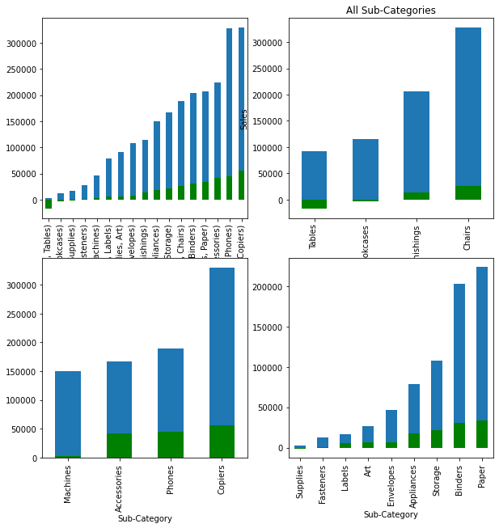

```python
#to see the sales and profit under each category
fig=plt.figure()
ax0=fig.add_subplot(2,2,1)
ax1=fig.add_subplot(2,2,2)
ax2=fig.add_subplot(2,2,3)
ax3=fig.add_subplot(2,2,4)

sales = df.groupby(["Category","Sub-Category"]).Sales.sum()
Profits = df.groupby(["Category","Sub-Category"]).Profit.sum()

sales["Furniture"].sort_values(ascending=True).plot(kind='bar',figsize=(10,10),ax=ax1)
ax1.set_title("Furniture")
ax1.set_xlabel("Sub-Categories")
ax1.set_ylabel("Sales")

sales["Technology"].sort_values(ascending=True).plot(kind='bar',figsize=(10,10),ax=ax2)
ax1.set_title("Technology")
ax1.set_xlabel("Sub-Categories")
ax1.set_ylabel("Sales")

sales["Office Supplies"].sort_values(ascending=True).plot(kind='bar',figsize=(10,10),ax=ax3)
ax1.set_title("Office Supplies")
ax1.set_xlabel("Sub-Categories")
ax1.set_ylabel("Sales")

sales.sort_values(ascending=True).plot(kind='bar',figsize=(10,10),ax=ax0)
ax1.set_title("All Sub-Categories")
ax1.set_xlabel("Sub-Categories")
ax1.set_ylabel("Sales")

Profits["Furniture"].sort_values(ascending=True).plot(kind='bar',figsize=(10,10),ax=ax1,color='green')
ax1.set_title("Furniture")
ax1.set_xlabel("Sub-Categories")
ax1.set_ylabel("Sales")

Profits["Technology"].sort_values(ascending=True).plot(kind='bar',figsize=(10,10),ax=ax2,color='green')
ax1.set_title("Technology")
ax1.set_xlabel("Sub-Categories")
ax1.set_ylabel("Sales")

Profits["Office Supplies"].sort_values(ascending=True).plot(kind='bar',figsize=(10,10),ax=ax3,color='green')
ax1.set_title("Office Supplies")
ax1.set_xlabel("Sub-Categories")
ax1.set_ylabel("Sales")

Profits.sort_values(ascending=True).plot(kind='bar',figsize=(10,10),ax=ax0,color='green')
ax1.set_title("All Sub-Categories")
ax1.set_xlabel("Sub-Categories")
ax1.set_ylabel("Sales")
```

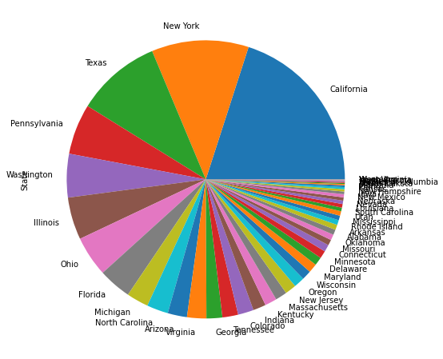

```python
#to knoe which state have larger customers
plt.figure(figsize=(10,8))
df['State'].value_counts().plot.pie()
plt.show()
```

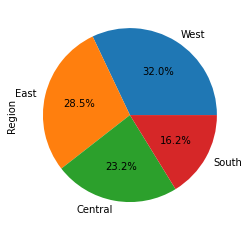

```python
#to know contribution of different region
df.Region.value_counts().plot.pie(autopct="%.1f%%")
plt.show()
```

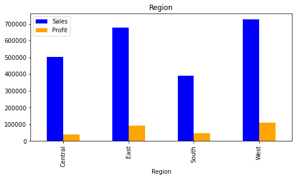

```python
#sales and profit in different regions
df.groupby('Region')['Sales','Profit'].sum().plot.bar(color=['blue','orange'])
plt.title('Region')
plt.legend(loc=0)
plt.show()
```

### Conclusion

Total sales is 22,97,200 and total profits are 2,86,397(12.47%).

Correlation between sales and profit is 0.48 (higher sales higher profits), While correlation between discount and profit is negative (higher discount lower will be profit).

Standard class is most commonly used mode of shipment.

Consumers are most significant segment for the business, it is good for business to launch schemes in consumer interest.

West region is giving maximum sales followed by east, central and south respectively.West region is giving maximum profits and sales. South have minimum sales and central region have minimum profits. West and east region are important for business.

California has the highest share of customers.

Binders, paper, furnishings , phones are important subcategories having maximum shares.

Sales and profit are maximum with 0 discount and profits become negative if discount rate is more than or equal to 0.3 Discounts should be minimised or removed to get more profits and sales. From the data, discounts are not benefiting the business even it is giving losses so discounts should be given with utmost care.

Technology have maximum sales and profits , furniture have very less profit as compared to sales so profit margin can be increased in furniture.